# Tidy data

### 12.2.1 Exercises

1. Using prose, describe how the variables and observations are organised in each of the sample tables.

In `table1`, each variable has its own column, each observation its own row, and each value its own cell. Therefore, `table1` is a tidy dataset.

In `table2`, the `cases` and `population` do not have their own columns, but rather, are treated as values. `table3` does not have the `cases` and `population` variables stored separately. Instead, both are stored as part of a calculation under `rate`. `table4a` stores the values of the `year` variable as separate variables (with their own columns), with the values being the number of cases (population is missing). `table 4b` is similar, but uses `population` for the values rather than `cases`.

2. Compute the `rate` for `table2`, and `table4a` + `table4b`. You will need to perform four operations:
   1. Extract the number of TB cases per country per year.
   2. Extract the matching population per country per year.
   3. Divide cases by population, and multiply by 10000.
   4. Store back in the appropriate place.

   Which representation is easiest to work with? Which is hardest? Why?

Extract the number of TB cases per country per year:

```r
table2_cases <- filter(table2, type == "cases")[["count"]]
```

Extract the matching population per country per year:

```r
table2_population <- filter(table2, type == "population")[["count"]]
```

Divide cases by population, and multiply by 10000:

```r
table2_rate <- table2_cases / table2_population * 10000
```

Store back in the appropriate place:

```r
table2_country <- filter(table2, type == "cases")[["country"]]
table2_year <- filter(table2, type == "cases")[["year"]]

table2_new <- tibble(
  country = table2_country,
  year = table2_year,
  cases = table2_cases,
  population = table2_population,
  rate = table2_rate
  )
table2_new
```

```
## # A tibble: 6 x 5
##       country  year  cases population     rate
##         <chr> <int>  <int>      <int>    <dbl>
## 1 Afghanistan  1999    745   19987071 0.372741
## 2 Afghanistan  2000   2666   20595360 1.294466
## 3      Brazil  1999  37737  172006362 2.193930
## 4      Brazil  2000  80488  174504898 4.612363
## 5       China  1999 212258 1272915272 1.667495
## 6       China  2000 213766 1280428583 1.669488
```

For `table4a` and `table4b`:

```r
table4_new <- tibble(
  country = table4a[["country"]],
  `1999` = table4a[["1999"]] / table4b[["1999"]] * 10000,
  `2000` = table4a[["2000"]] / table4b[["2000"]] * 10000
  )
table4_new
```

```
## # A tibble: 3 x 3
##       country   `1999`   `2000`
##         <chr>    <dbl>    <dbl>
## 1 Afghanistan 0.372741 1.294466
## 2      Brazil 2.193930 4.612363
## 3       China 1.667495 1.669488
```

3. Recreate the plot showing change in cases over time using `table2` instead of `table1`. What do you need to do first?

Filter `cases`:

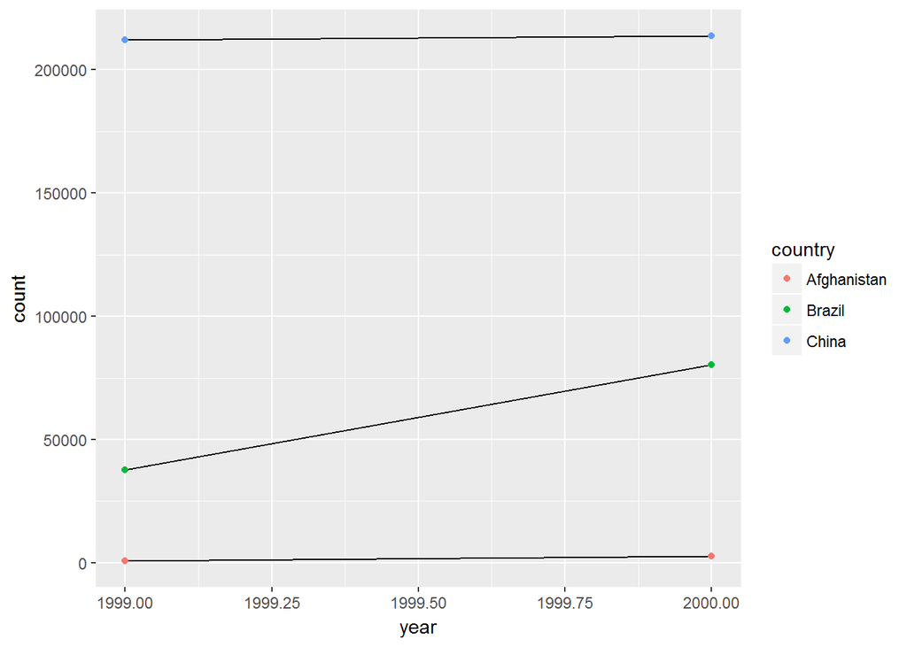

```r
table2 %>%
  filter(type == "cases") %>%
  ggplot(aes(year, count)) +
    geom_line(aes(group = country)) +
    geom_point(aes(colour = country))
```

### 12.3.3 Exercises

1. Why are `gather()` and `spread()` not perfectly symmetrical?  
   Carefully consider the following example:

   ```r
   stocks <- tibble(
     year   = c(2015, 2015, 2016, 2016),
     half  = c(   1,    2,     1,    2),
     return = c(1.88, 0.59, 0.92, 0.17)
   )
   stocks %>%
     spread(year, return) %>%
     gather("year", "return", `2015`:`2016`)
   ```

   (Hint: look at the variable types and think about column *names*.)

   Both `spread()` and `gather()` have a `convert` argument. What does it do?

`gather()` and `spread()` are not perfectly symmetrical because variable type is not retained when using both functions, as seen in the example above. In `stocks`, `year` is numeric:

```r
stocks %>% select(year)
```

```
## # A tibble: 4 x 1
##    year
##   <dbl>
## 1  2015
## 2  2015
## 3  2016
## 4  2016
```

However, after using the `spread()` and `gather()` functions it becomes `character`:

```r
stocks %>%
  spread(year, return) %>%
  gather("year", "return", `2015`:`2016`) %>%
  select(year)
```

```
## # A tibble: 4 x 1
##    year
##   <chr>
## 1  2015
## 2  2015
## 3  2016
## 4  2016
```

The `convert` argument, when set to `TRUE`, will retain numeric, integer, or logical column types when using `spread()` or `gather()`.

2. Why does this code fail?

   ```r
   table4a %>%
     gather(1999, 2000, key = "year", value = "cases")
   ```

   ```
   ## Error in inds_combine(.vars, ind_list): Position must be between 0 and n
   ```

“1999” and “2000” are non-syntactic names so they have to be surrounded by backticks.

```r
table4a %>%
  gather(`1999`, `2000`, key = "year", value = "cases")
```

```
## # A tibble: 6 x 3
##       country  year  cases
##         <chr> <chr>  <int>
## 1 Afghanistan  1999    745
## 2      Brazil  1999  37737
## 3       China  1999 212258
## 4 Afghanistan  2000   2666
## 5      Brazil  2000  80488
## 6       China  2000 213766
```

3. Why does spreading this tibble fail? How could you add a new column to fix the problem?

   ```r
   people <- tribble(
     ~name,             ~key,    ~value,
     #-----------------|--------|------
     "Phillip Woods",   "age",       45,
     "Phillip Woods",   "height",   186,
     "Phillip Woods",   "age",       50,
     "Jessica Cordero", "age",       37,
     "Jessica Cordero", "height",   156
   )
   ```

```r
people %>% spread(key, value)
```

```
## Error: Duplicate identifiers for rows (1, 3)
```

Phillip Woods’ age has been entered twice. You could add a new column that indicates the time of observation:

```r
people <- tribble(
  ~name,             ~key,    ~value, ~time,
  #-----------------|--------|------|-------
  "Phillip Woods",   "age",       45, 1,
  "Phillip Woods",   "height",   186, 1,
  "Phillip Woods",   "age",       50, 2,
  "Jessica Cordero", "age",       37, 1,
  "Jessica Cordero", "height",   156, 1
)
```

```r
people %>% spread(key, value)
```

```
## # A tibble: 3 x 4
##              name  time   age height
## *           <chr> <dbl> <dbl>  <dbl>
## 1 Jessica Cordero     1    37    156
## 2   Phillip Woods     1    45    186
## 3   Phillip Woods     2    50     NA
```

4. Tidy the simple tibble below. Do you need to spread or gather it? What are the variables?

   ```r
   preg <- tribble(
     ~pregnant, ~male, ~female,
     "yes",     NA,    10,
     "no",      20,    12
   )
   ```

It needs to be gathered. The variables are sex (male or female) and pregnant (yes or no).

```r
preg %>% gather(
  male, female,
  key = "sex",
  value = "count"
)
```

```
## # A tibble: 4 x 3
##   pregnant    sex count
##      <chr>  <chr> <dbl>
## 1      yes   male    NA
## 2       no   male    20
## 3      yes female    10
## 4       no female    12
```

### 12.4.3 Exercises

1. What do the `extra` and `fill` arguments do in `separate()`? Experiment with the various options for the following two toy datasets.

   ```r
   tibble(x = c("a,b,c", "d,e,f,g", "h,i,j")) %>%
     separate(x, c("one", "two", "three"))

   tibble(x = c("a,b,c", "d,e", "f,g,i")) %>%
     separate(x, c("one", "two", "three"))
   ```

`extra` controls what happens when you use a character vector in `sep` and there are too many pieces.

```r
tibble(x = c("a,b,c", "d,e,f,g", "h,i,j")) %>%
  separate(x, c("one", "two", "three"), extra = "merge")
```

```
## # A tibble: 3 x 3
##     one   two three
## * <chr> <chr> <chr>
## 1     a     b     c
## 2     d     e   f,g
## 3     h     i     j
```

In comparison, `fill` controls what happens when there are not enough pieces.

```r
tibble(x = c("a,b,c", "d,e", "f,g,i")) %>%
  separate(x, c("one", "two", "three"), fill = "left")
```

```
## # A tibble: 3 x 3
##     one   two three
## * <chr> <chr> <chr>
## 1     a     b     c
## 2  <NA>     d     e
## 3     f     g     i
```

2. Both `unite()` and `separate()` have a `remove` argument. What does it do? Why would you set it to `FALSE`?

It removes the input column from the data frame. By setting this to `FALSE`, you can retain the original input column in the dataset:

```r
tibble(x = c("a,b,c", "d,e,f", "g,h,i")) %>%
  separate(x, c("one", "two", "three"), remove = "FALSE")
```

```
## # A tibble: 3 x 4
##       x   one   two three
## * <chr> <chr> <chr> <chr>
## 1 a,b,c     a     b     c
## 2 d,e,f     d     e     f
## 3 g,h,i     g     h     i
```

3. Compare and contrast `separate()` and `extract()`. Why are there three variations of separation (by position, by separator, and with groups), but only one unite?

```r
tibble(x = c("a,b,c", "d,e,f", "g,h,i")) %>%
  separate(x, c("one", "two", "three"))
```

```
## # A tibble: 3 x 3
##     one   two three
## * <chr> <chr> <chr>
## 1     a     b     c
## 2     d     e     f
## 3     g     h     i
```

```r
tibble(x = c("a,b,c", "d,e,f", "g,h,i"))
```

```
## # A tibble: 3 x 1
##       x
##   <chr>
## 1 a,b,c
## 2 d,e,f
## 3 g,h,i
```

```r
tibble(x = c("a,b,c", "d,e,f", "g,h,i")) %>%
  extract(x, "A")
```

```
## # A tibble: 3 x 1
##       A
## * <chr>
## 1     a
## 2     d
## 3     g
```

`separate()` pulls apart one column and places the values into many columns. `extract()` is a similar function, but, as its name implies, only retains values you wish to extract from a data frame.

`unite()` only requires one variation of separation because it is combining multiple columns into one column. Therefore, there is only one way to do it (using `sep`). In comparison, there are multiple ways to split a character string for `separate()` (e.g., by position or by separator).

### 12.5.1 Exercises

1. Compare and contrast the `fill` arguments to `spread()` and `complete()`.

For `spread()`, `fill` will replace missing values in a data set with this value. In comparison, the `fill` argument for `complete()` allows you to replace missing values by column name.

2. What does the direction argument to `fill()` do?

It is the direction in which to fill missing values. For example:

```r
df <- data.frame(Month = 1:12, Year = c(NA, 2000, rep(NA, 10)))
df %>% fill(Year, .direction = c("up"))
```

```
##    Month Year
## 1      1 2000
## 2      2 2000
## 3      3   NA
## 4      4   NA
## 5      5   NA
## 6      6   NA
## 7      7   NA
## 8      8   NA
## 9      9   NA
## 10    10   NA
## 11    11   NA
## 12    12   NA
```

### 12.6.1 Exercises

1. In this case study I set `na.rm = TRUE` just to make it easier to check that we had the correct values. Is this reasonable? Think about how missing values are represented in this dataset. Are there implicit missing values? What’s the difference between an `NA` and zero?

I think this is reasonable. Missing values appear to be represented explicitely in this dataset:

```r
who %>%
  gather(new_sp_m014:newrel_f65, key = "key", value = "cases") %>%
  count(is.na(cases))
```

```
## # A tibble: 2 x 2
##   `is.na(cases)`      n
##            <lgl>  <int>
## 1          FALSE  76046
## 2           TRUE 329394
```

It is difficult to determine whether there are implicit missing values in a dataset because, as stated earlier in the chapter, implicit missing values are an “absence of a presence”.

`NA` indicates an explicit missing value. So, the number of actual cases for an `NA` observation is not necessarily zero. In comparison, a value of zero indicates there were no cases for a particular observation.

```r
who %>%
  gather(new_sp_m014:newrel_f65, key = "key", value = "cases") %>%
  filter(cases == 0) %>%
  nrow()
```

```
## [1] 11080
```

2. What happens if you neglect the `mutate()` step? (`mutate(key = stringr::str_replace(key, "newrel", "new_rel"))`)

```r
who %>%
  gather(code, value, new_sp_m014:newrel_f65, na.rm = TRUE) %>%
  separate(code, c("new", "var", "sexage")) %>%
  select(-new, -iso2, -iso3) %>%
  separate(sexage, c("sex", "age"), sep = 1)
```

```
## # A tibble: 76,046 x 6
##        country  year   var   sex   age value
##  *       <chr> <int> <chr> <chr> <chr> <int>
##  1 Afghanistan  1997    sp     m   014     0
##  2 Afghanistan  1998    sp     m   014    30
##  3 Afghanistan  1999    sp     m   014     8
##  4 Afghanistan  2000    sp     m   014    52
##  5 Afghanistan  2001    sp     m   014   129
##  6 Afghanistan  2002    sp     m   014    90
##  7 Afghanistan  2003    sp     m   014   127
##  8 Afghanistan  2004    sp     m   014   139
##  9 Afghanistan  2005    sp     m   014   151
## 10 Afghanistan  2006    sp     m   014   193
## # ... with 76,036 more rows
```

It won’t split the string `newrel` properly.

```r
split_problem <- who %>%
  gather(code, value, new_sp_m014:newrel_f65, na.rm = TRUE) %>%
  separate(code, c("new", "var", "sexage")) %>%
  select(-new, -iso2, -iso3) %>%
  separate(sexage, c("sex", "age"), sep = 1)
split_problem %>% slice(73467:73486)
```

```
## # A tibble: 20 x 6
##                country  year   var   sex   age value
##                  <chr> <int> <chr> <chr> <chr> <int>
##  1         Afghanistan  2013  m014  <NA>  <NA>  1705
##  2             Albania  2013  m014  <NA>  <NA>    14
##  3             Algeria  2013  m014  <NA>  <NA>    25
##  4             Andorra  2013  m014  <NA>  <NA>     0
##  5              Angola  2013  m014  <NA>  <NA>   486
##  6            Anguilla  2013  m014  <NA>  <NA>     0
##  7 Antigua and Barbuda  2013  m014  <NA>  <NA>     1
##  8           Argentina  2013  m014  <NA>  <NA>   462
##  9             Armenia  2013  m014  <NA>  <NA>    25
## 10           Australia  2013  m014  <NA>  <NA>    28
## 11             Austria  2013  m014  <NA>  <NA>    15
## 12          Azerbaijan  2013  m014  <NA>  <NA>   125
## 13             Bahamas  2013  m014  <NA>  <NA>     3
## 14             Bahrain  2013  m014  <NA>  <NA>     4
## 15          Bangladesh  2013  m014  <NA>  <NA>  2323
## 16            Barbados  2013  m014  <NA>  <NA>     0
## 17             Belarus  2013  m014  <NA>  <NA>     4
## 18             Belgium  2013  m014  <NA>  <NA>    40
## 19              Belize  2013  m014  <NA>  <NA>     1
## 20               Benin  2013  m014  <NA>  <NA>    25
```

For relapse cases, gender and age group have not separated (they appear under `var`), and `sex` and `age` variables are `NA`.

3. I claimed that `iso2` and `iso3` were redundant with `country`. Confirm this claim.

For each country, there is only one unique combination of `iso2` and `iso3`:

```r
who %>%
  gather(new_sp_m014:newrel_f65, key = "key", value = "cases", na.rm = TRUE) %>%
  select(country, iso2, iso3) %>%
  distinct() %>%
  group_by(country) %>%
  filter(n() > 1)
```

```
## # A tibble: 0 x 3
## # Groups:   country [0]
## # ... with 3 variables: country <chr>, iso2 <chr>, iso3 <chr>
```

4. For each country, year, and sex compute the total number of cases of TB. Make an informative visualisation of the data.

```r
who_cases <- who %>%
  gather(code, value, new_sp_m014:newrel_f65, na.rm = TRUE) %>%
  mutate(code = stringr::str_replace(code, "newrel", "new_rel")) %>%
  separate(code, c("new", "var", "sexage")) %>%
  select(-new, -iso2, -iso3) %>%
  separate(sexage, c("sex", "age"), sep = 1) %>%
  group_by(country, year, sex) %>%
  summarise(cases = sum(value))

who_cases
```

```
## # A tibble: 6,921 x 4
## # Groups:   country, year [?]
##        country  year   sex cases
##          <chr> <int> <chr> <int>
##  1 Afghanistan  1997     f   102
##  2 Afghanistan  1997     m    26
##  3 Afghanistan  1998     f  1207
##  4 Afghanistan  1998     m   571
##  5 Afghanistan  1999     f   517
##  6 Afghanistan  1999     m   228
##  7 Afghanistan  2000     f  1751
##  8 Afghanistan  2000     m   915
##  9 Afghanistan  2001     f  3062
## 10 Afghanistan  2001     m  1577
## # ... with 6,911 more rows
```

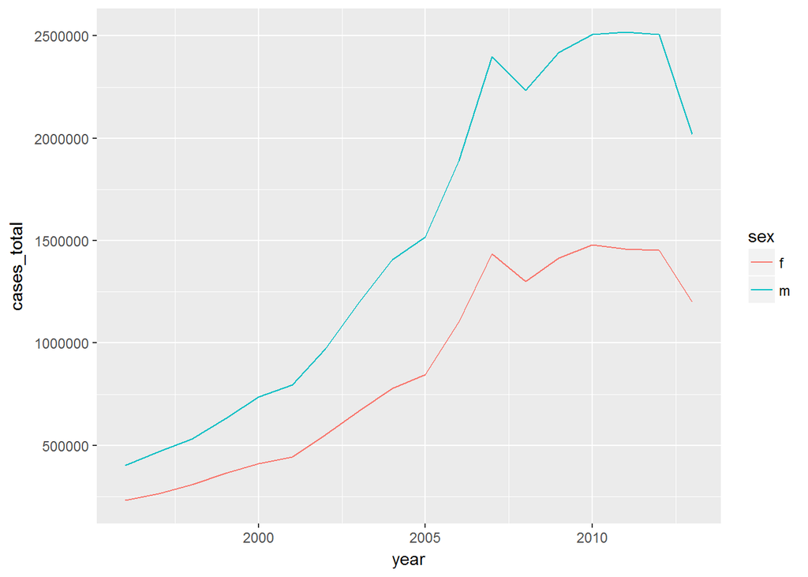

```r
who_cases %>%
  group_by(sex, year) %>%
  filter(year > 1995) %>%
  summarise(cases_total = sum(cases)) %>%
  ggplot(aes(x = year, y = cases_total, group = sex, colour = sex)) +
    geom_line()
```